# Lecture 2

Some practical tips on `inlabru`

Sara Martino

sara.martino@ntnu.no

Dept. of Mathematical Science, NTNU

Janine Illian

Janine.Illian@glasgow.ac.uk

University of Glasgow

Jafet Belmont

Jafet.Belmont@glasgow.ac.uk

University of Glasgow

## Fitting a LGM with `inlabru`

The general workflow:

```r
# Define model components
comps <- component_1(...) +
  component_2(...) +
  ...

# Define the model predictor
pred <- linear_function(component_1,
                            component_2, ...)

# Build the observation model
lik <- bru_obs(formula = pred,
               family = ... ,
               data = ... ,
                ...)

# Fit the model
fit <- bru(comps, lik, ...)
```

## Fitting a LGM with `inlabru`

The general workflow:

```r
# Define model components
comps <- component_1(...) +
  component_2(...) +
  ...

# Define the model predictor
pred <- linear_function(component_1,
                            component_2, ...)

# Build the observation model
lik <- bru_obs(formula = pred,
               family = ... ,
               data = ... ,
                ...)

# Fit the model
fit <- bru(comps, lik, ...)
```

# Basic `component` features

## Basic `component` features

The basic syntax for components is:

```r
~ my_component_name(
  main = ...,
  model = ...
)
```

- `my_component_name`: this is a user-chosen label for the model component. This is then used as input in `predict()` and `generate()`.
- `main`: here we define the input data for the component.
- `model`: The type of model component see `?component`, and `?INLA::inla.list.models()$latent`.

**Examples**

- `beta_0(1)` or `Intercept(1)` define one intercept
- `cov_effect(altitude, model= "linear")` defines the linear effect of `altitude` on the predictor.
- `time_effect(time, model= "rw2")` defines the smooth effect of `time` on the predictor.

# Shortcuts

## Some `inlabru` shortcuts

In the slides we have fitted the model as:

```r
cmp = ~ -1 + beta0(1) beta1(covariate, model = "linear")
formula = y ~ beta0 + beta1
lik = bru_obs(formula = formula,
              famuly  = "gaussian",
              data = df)
fit = bry(cmp, lik)
```

but in the practical you have

```r
cmp = ~ -1 + beta0(1) beta1(covariate, model = "linear")

lik = bru_obs(formula = y~.,
              famuly  = "gaussian",
              data = df)
fit = bry(cmp, lik)
```

## Some `inlabru` shortcuts

In the slides we have fitted the model as:

```r
cmp = ~ -1 + beta0(1) beta1(covariate, model = "linear")
formula = y ~ beta0 + beta1
lik = bru_obs(formula = formula,
              famuly  = "gaussian",
              data = df)
fit = bru(cmp, lik)
```

but in the practical you have

```r
cmp = ~ -1 + beta0(1) beta1(covariate, model = "linear")

lik = bru_obs(formula = y~.,
              famuly  = "gaussian",
              data = df)
fit = bru(cmp, lik)
```

1. You *don’t have to* define a formula outside of the `bru_obs()` function..it can be defines also inside the function!

```r
lik = bru_obs(formula = y~  beta0 + beta1,
              famuly  = "gaussian",
              data = df)
```

2. The expression `y ~ .` just means “*take all the components and sum them together*”. It also tells the `bru()` function that your predictor is *linear*.

## Why do we need the -1 in the formula?

- `inlabru` provides a dedicated term, `Intercept()`, for specifying an intercept that is shared across all data.
- When this term is omitted, a common intercept is added by default, unless the formula or component explicitly includes `-1`.

## One wrong and two correct ways of coding

```r
# This is WRONG as we get an intercept too much :-)
cmp = ~ beta0(1) + beta1(covariate, model = "linear")
lik = bru_obs(formula = y ~ . ,
              data = df)
m1 = bru(cmp, lik)
round(m1$summary.fixed[,c(1,2)],3)
```

```
           mean     sd
beta0     0.445 22.361
beta1     0.736  0.326
Intercept 0.445 22.361
```

```r
# This is correct..
cmp = ~ Intercept(1) + beta1(covariate, model = "linear")
lik = bru_obs(y~ .,
              data = df)
m1 = bru(cmp, lik)
round(m1$summary.fixed[,c(1,2)],3)
```

```
           mean    sd
Intercept 0.890 0.174
beta1     0.736 0.326
```

```r
# This is also correct
cmp = ~  -1 + beta0(1) + beta1(covariate, model = "linear")
lik = bru_obs(y~. ,
              data = df)
m1 = bru(cmp, lik)
round(m1$summary.fixed[,c(1,2)],3)
```

```
       mean    sd
beta0 0.890 0.174
beta1 0.736 0.326
```

# Categorical variables and interactions

## Effects of categorical variables and Interactions

`inlabru` has a specific component type for this that is called `fixed`.

Let’s look at the `mtcars` dataset that is in `R`

```
                   mpg cyl disp  hp drat    wt  qsec vs am gear carb
Mazda RX4         21.0   6  160 110 3.90 2.620 16.46  0  1    4    4
Mazda RX4 Wag     21.0   6  160 110 3.90 2.875 17.02  0  1    4    4
Datsun 710        22.8   4  108  93 3.85 2.320 18.61  1  1    4    1
Hornet 4 Drive    21.4   6  258 110 3.08 3.215 19.44  1  0    3    1
Hornet Sportabout 18.7   8  360 175 3.15 3.440 17.02  0  0    3    2
Valiant           18.1   6  225 105 2.76 3.460 20.22  1  0    3    1
```

## Effects of categorical variables in `inlabru`

We want to fit a model where `gear` is the only covariate.

- `gear` has three categories: `3`, `4` and `5`
- We want to model it as a factor effect

```r
mtcars$gear = factor(mtcars$gear)
m1 = lm(mpg~ gear, data = mtcars)
m1$coef
```

```
(Intercept)       gear4       gear5
  16.106667    8.426667    5.273333
```

How do we do this in `inlabru`?

## Effects of categorical variables in `inlabru`

**Option 1**: Use the `fixed` model

```r
# create the model matrix

cmp1 = ~ -1 + gear0(~ gear, model = "fixed")
lik1 = bru_obs(formula = mpg ~.,
               data = mtcars)
fit1 = bru(cmp1, lik1)
fit1$summary.random$gear0[,c(1:3)]
```

```
           ID      mean       sd
1 (Intercept) 16.103112 1.205027
2       gear4  8.414875 1.807342
3       gear5  5.253896 2.407237
```

**NOTE**

- `gear0(~ gear, model = "fixed")` is a `lm` style model definition! So an intercept is automatically included
- The results are stored in the `summary.random` part of the model, not the `summary.fixed`

## Effects of categorical variables in `inlabru`

- **Option 2:** Fixed effect are just random effects with fixed precision 😄

```r
cmp2 = ~ -1 +  gear_effect(gear, model = "iid", fixed = T,initial = -6)
# or: cmp2 = ~ Intercept(1) +  gear_effect(gear_id, model = "iid", fixed = T,initial = -6, constr = T)
lik2 = bru_obs(formula = mpg ~.,
               data = mtcars)
fit2 = bru(cmp2, lik2)
fit2$summary.random$gear_effect$mean
```

```
[1] 16.04855 24.42278 21.15033
```

What is happening here??

This is just a re-parametrization problem

```r
c(m1$coef[1], m1$coef[1] + m1$coef[2],m1$coef[1] + m1$coef[3])
```

## Effects of categorical variables in `inlabru`

Alternative (and equivalent) coding options

```r
cmp1 = ~ -1 + gear(~ gear, model = "fixed")     #One reference category
cmp2 = ~ -1 + gear( ~ gear -1, model = "fixed") # No common intercept
cmp3 = ~ -1 + gear(gear, model = "iid", fixed = T,initial = -6) # No common intercept
```

**NOTE**

When using the `fixed` model, `inlabru` internally creates a model matrix using the function `MatrixModels::model.Matrix()`. The syntax

```r
cmp1 = ~ -1 + gear(main = ~ gear,
                   model = "fixed")     #One reference category
```

is equivalent to

```r
cmp1 = ~ -1 + gear(main = ~ MatrixModels::model.Matrix(gear, .data.),
                   model = "fixed")     #One reference category
```

## Interactions of linear covariates in `inlabru`

Here the easiest option is to use again the `fixed` model type.

**Example 1**

Say we want to fit a model with interactions between (**categorical**) `gear` and (**bivariate**) `vs`.

In `lm` we can do

```r
m2 = lm(mpg ~ gear * vs, data = mtcars)
m2$coefficients
```

```
(Intercept)       gear4       gear5          vs    gear4:vs    gear5:vs
  15.050000    5.950000    4.075000    5.283333   -1.043333    5.991667
```

Similarly in `inlabru`

```r
cmp = ~ -1 + fixed_effects( ~ (gear * vs), model = "fixed")
lik = bru_obs(formula = mpg ~ .,
              data = mtcars)
fit = bru(cmp, lik)
fit$summary.random$fixed_effects$mean
```

```
[1] 15.0434624  5.8986288  4.0890388  5.2876289 -0.9880638  5.8809905
```

```r
fit$summary.random$fixed_effects$sd
```

```
[1] 1.179235 3.100019 2.353196 2.618198 4.074736 5.205994
```

## Interactions of linear covariates in `inlabru`

**Example 2**

Another example, this time interaction between (**categorical**) `gear` and (**continuous**) `disp`.

Using `lm`:

```r
m2 = lm(mpg ~ gear * disp, data = mtcars)
m2$coef
```

```
(Intercept)       gear4       gear5        disp  gear4:disp  gear5:disp
24.51556635 15.05196338  7.14538044 -0.02577046 -0.09644222 -0.02500467
```

Using `inlabru` and the `fixed` model

```r
cmp = ~ -1 + fixed_effects(~gear * disp, model = "fixed")
lik = bru_obs(formula = mpg ~ .,
              data = mtcars)
fit = bru(cmp, lik)
fit$summary.random$fixed_effects$mean
```

```
[1] 24.50106644 14.96913649  7.11471930 -0.02572927 -0.09575870 -0.02486888
```

## Interactions of linear covariates in `inlabru`

We can also use the idea that “fixed effects are just random effects with fixed precision” 😄

**NOTE:** This idea can be very useful in more complex contexts where the `fixed` model does not work (for example if one wants to have spatially varying effect of a covariate!)

Let’s look at the interaction between (**categorical**) `gear` and (**continuous**) `disp`.

$$\begin{aligned}
\eta_i & = \beta_0 + \beta_{0,\text{GEAR}_i} + \beta_1x_i + \beta_{1,\text{GEAR}_i} x_i\\
& = \beta^*_{0,\text{GEAR}_i} +\beta^*_{1,\text{GEAR}_i} x_i
\end{aligned}$$

## Interactions of linear covariates in `inlabru`

We can also use the idea that “fixed effects are just random effects with fixed precision” 😄

**NOTE:** This idea can be very useful in more complex contexts where the `fixed` model does not work (for example if one wants to have spatially varying effect of a covariate!)

Let’s look at the interaction between (**categorical**) `gear` and (**continuous**) `disp`.

$$\begin{aligned}
\eta_i & = \beta_0 + \beta_{0,\text{GEAR}_i} + \beta_1x_i + \beta_{1,\text{GEAR}_i} x_i\\
& = \underbrace{\beta^*_{0,\text{GEAR}_i}}_{\text{iid}} +\underbrace{\beta^*_{1,\text{GEAR}_i}}_{\text{iid}}\ \underbrace{x_i}_{\text{weights}}
\end{aligned}$$

## Interactions of linear covariates in `inlabru`

The model for the linear predictor is:

```r
cmp = ~ -1 + beta0(gear, model = "iid", initial = -6, fixed = T) +
  beta1(gear, disp, model = "iid", initial = -6, fixed = T)
lik = bru_obs(formula = mpg ~ .,
              data = mtcars)
fit = bru(cmp, lik)

fit$summary.random$beta0$mean
```

```
[1] 24.15664 38.93821 31.16917
```

```r
fit$summary.random$beta1$mean
```

```
[1] -0.02475087 -0.11752667 -0.04884794
```

Compare with the `lm` results

```r
m2$coefficients
```

```
(Intercept)       gear4       gear5        disp  gear4:disp  gear5:disp
24.51556635 15.05196338  7.14538044 -0.02577046 -0.09644222 -0.02500467
```

The difference is just in the different parametrization 😄

# Getting results from the fitted model

## The `result` object

The fitted model is stored in an `inlabru` object

```r
library(car)
data("Salaries")
# it is a good idea to scale the response
Salaries$salary  = Salaries$salary/1000
```

```r
Salaries[1:3,]
```

```
      rank discipline yrs.since.phd yrs.service  sex salary
1     Prof          B            19          18 Male 139.75
2     Prof          B            20          16 Male 173.20
3 AsstProf          B             4           3 Male  79.75
```

```r
cmp = ~ Intercept(1) + sex(sex, model = "iid", initial = -6, fixed = T) +
  time(yrs.since.phd, model = "linear")
lik = bru_obs(formula = salary ~ .,
              data = Salaries)
result = bru(cmp, lik)
summary(result)
```

```
inlabru version: 2.13.0.9033
INLA version: 26.02.06
Latent components:
Intercept: main = linear(1)
sex: main = iid(sex)
time: main = linear(yrs.since.phd)
Observation models:
  Model tag: <No tag>
    Family: 'gaussian'
    Data class: 'data.frame'
    Response class: 'numeric'
    Predictor: salary ~ Intercept + sex + time
    Additive/Linear/Rowwise: TRUE/TRUE/TRUE
    Used components: effect[Intercept, sex, time], latent[]
Time used:
    Pre = 0.492, Running = 0.19, Post = 0.014, Total = 0.696
Fixed effects:
            mean     sd 0.025quant 0.5quant 0.975quant   mode kld
Intercept 73.634 13.214     47.722   73.634     99.546 73.634   0
time       0.976  0.108      0.764    0.976      1.188  0.976   0

Random effects:
  Name    Model
    sex IID model

Model hyperparameters:
                                         mean   sd 0.025quant 0.5quant
Precision for the Gaussian observations 0.001 0.00      0.001    0.001
                                        0.975quant  mode
Precision for the Gaussian observations      0.002 0.001

Marginal log-Likelihood:  -1909.39
 is computed
Posterior summaries for the linear predictor and the fitted values are computed
(Posterior marginals needs also 'control.compute=list(return.marginals.predictor=TRUE)')
```

## Getting results I

Some results are very easy to get as they are contained in the `result` object:

- Summaries for fixed effects

```r
result$summary.fixed
```

```
                mean         sd 0.025quant   0.5quant 0.975quant       mode
Intercept 73.6338668 13.2142639 47.7218377 73.6339188  99.545600 73.6339190
time       0.9758411  0.1079614  0.7641549  0.9757971   1.187779  0.9757972
                   kld
Intercept 5.468309e-11
time      3.966806e-10
```

- Summaries for random effects

```r
result$summary.random$sex
```

```
      ID     mean       sd 0.025quant 0.5quant 0.975quant     mode          kld
1 Female 10.74085 13.21356 -15.169724 10.74088   36.65129 10.74088 5.470145e-11
2   Male 18.96517 13.12601  -6.773644 18.96517   44.70400 18.96517 5.501394e-11
```

- Summaries for hyperparameters

```r
result$summary.hyperpar
```

```
                                               mean          sd  0.025quant
Precision for the Gaussian observations 0.001332104 9.44603e-05 0.001152964
                                           0.5quant  0.975quant        mode
Precision for the Gaussian observations 0.001329884 0.001523951 0.001325018
```

## Getting results I

- Marginals for fixed effects

```r
result$marginals.fixed$Intercept[1:3,]
```

```
            x            y
[1,] 17.31393 3.445719e-06
[2,] 24.47190 2.993035e-05
[3,] 32.77900 2.546511e-04
```

- Summaries for random effects

```r
result$marginals.random$sex$index.1[1:3,]
```

```
             x            y
[1,] -45.57561 3.445950e-06
[2,] -38.41813 2.993244e-05
[3,] -30.11160 2.546681e-04
```

- Summaries for hyperparameters

```r
result$marginals.hyperpar$`Precision for the Gaussian observations`[1:3,]
```

```
               x         y
[1,] 0.001003775  4.078690
[2,] 0.001018635  8.164013
[3,] 0.001059874 43.850525
```

## `predict()` and `generate()` functions

Often one wants more “complex” results from the model.

For example if we fit to the `mtcar` data, the model

$$\eta_i = \beta_{0,\text{GEAR}_i} + \beta_{1,\text{GEAR}_i}x_i,\ i =1,\dots,n$$

We might want to recover the three regression lines

$$\beta_{0,\text{GEAR}_i} + \beta_{1,\text{GEAR}_i}x_i ,\ \text{GEAR} = 3,4,5$$

To do this we can use the `predict()` and `generate()` functions.

- `predict()` *simulates* from the fitted posterior distribution $\pi(\mathbf{y}|\mathbf{u},\theta)$, computes what you ask and produces a summary of the samples (mean, sd, quantiles, etc)
- `generate()` *simulates* from the fitted posterior distribution $\pi(\mathbf{y}|\mathbf{u},\theta)$, computes what you ask and return the samples!

## Example 1

```r
cmp = ~ -1 + fixed_effects(~gear * disp, model = "fixed")
lik = bru_obs(formula = mpg ~ .,
              data = mtcars)
fit = bru(cmp, lik)

new_data  = data.frame(gear = factor(rep(3:5, each = 400)),
           disp = seq(71,470,1))
res = predict(fit, new_data, ~ fixed_effects)

res[1:5,]
```

```
  gear disp     mean       sd   q0.025     q0.5   q0.975   median
1    3   71 22.39604 2.034613 18.99907 22.54192 26.31040 22.54192
2    3   72 22.37112 2.027809 18.98687 22.51678 26.27229 22.51678
3    3   73 22.34619 2.021007 18.97468 22.49164 26.23418 22.49164
4    3   74 22.32127 2.014208 18.96248 22.46650 26.19608 22.46650
5    3   75 22.29635 2.007411 18.95029 22.44135 26.15797 22.44135
  mean.mc_std_err sd.mc_std_err
1       0.2369176     0.1672814
2       0.2361205     0.1666981
3       0.2353237     0.1661147
4       0.2345271     0.1655314
5       0.2337307     0.1649481
```

## Example 1

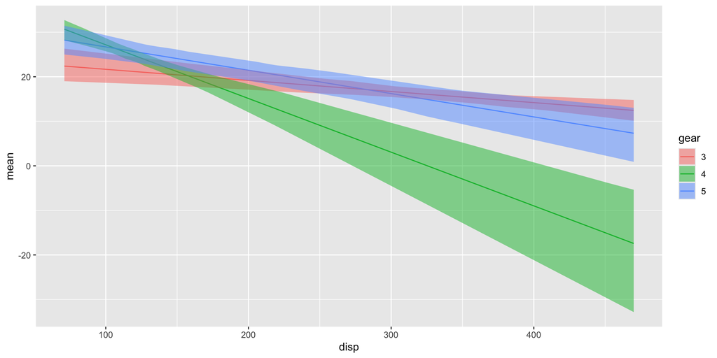

```r
res %>% ggplot() + geom_line(aes(disp, mean, group = gear, color = gear)) +
  geom_ribbon(aes(disp, ymin = q0.025 , ymax = q0.975,
                  group = gear, fill = gear), alpha = 0.5)
```

## Example 2

```r
cmp = ~ -1 + beta0(gear, model = "iid", initial = -6, fixed = T) +
  beta1(gear, disp, model = "iid", initial = -6, fixed = T)
lik = bru_obs(formula = mpg ~ .,
              data = mtcars)
fit = bru(cmp, lik)

res = predict(fit, new_data, ~ beta0 + beta1)

res[1:5,]
```

```
  gear disp     mean       sd   q0.025     q0.5   q0.975   median
1    3   71 22.20469 2.082109 17.86798 22.45977 25.67829 22.45977
2    3   72 22.18086 2.074446 17.85878 22.43372 25.64251 22.43372
3    3   73 22.15703 2.066786 17.84957 22.40766 25.60673 22.40766
4    3   74 22.13320 2.059129 17.84037 22.38161 25.57094 22.38161
5    3   75 22.10936 2.051474 17.83117 22.35555 25.53516 22.35555
  mean.mc_std_err sd.mc_std_err
1       0.2387793     0.1528418
2       0.2379132     0.1523430
3       0.2370475     0.1518446
4       0.2361822     0.1513464
5       0.2353171     0.1508486
```

## Example 2

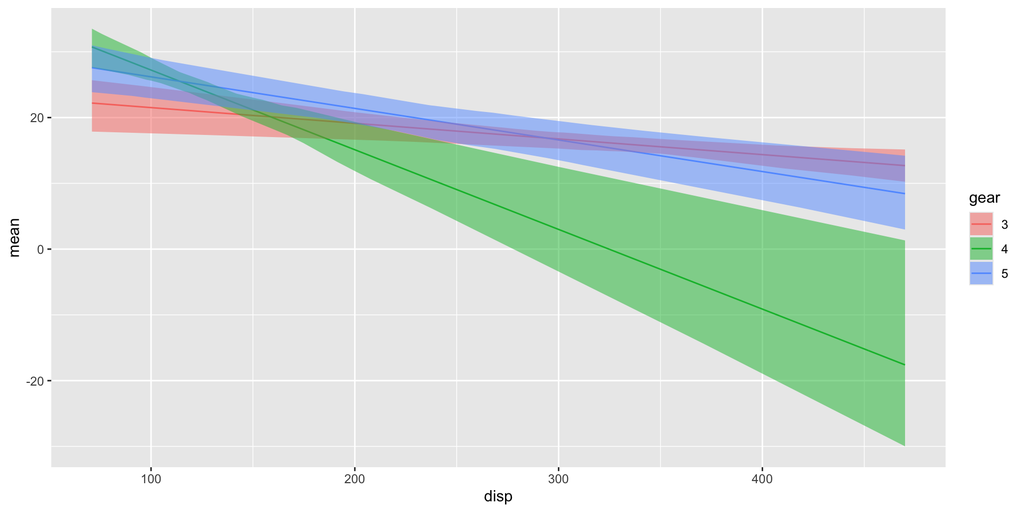

```r
res %>% ggplot() + geom_line(aes(disp, mean, group = gear, color = gear)) +
  geom_ribbon(aes(disp, ymin = q0.025 , ymax = q0.975,
                  group = gear, fill = gear), alpha = 0.5)
```

## Yet another example

Let’s fit the model for the Tokyo rainfall data
$$\begin{aligned}
y_t|\eta_t&\sim\text{Bin}(n_t, p_t),\qquad i = 1,\dots,366\\
\eta_t &= \text{logit}(p_t)= \beta_0 + f(\text{time}_t)
\end{aligned}$$

```r
data("Tokyo")
cmp= ~ -1 + Intercept(1) + time(time, model ="rw2")
formula = y ~ Intercept + time
lik = bru_obs(formula = formula,
              data = Tokyo,
              Ntrials = n,
              family = "binomial")
fit = bru(cmp, lik)
```

We now want to extract results…what do we want?

- The time effect $f(\text{time}_t)$ ?
- The linear predictor $\eta_t = \beta_0 + f(\text{time}_t)$?
- The estimated probability offit precipitation $p_t = \text{inv_logit}(\eta_t)$ ?

We can get all of them with the `predict()` or `generate()` functions!

## Example - `predict()`

```r
preds1 = predict(object = fit, newdata = Tokyo, ~ time)
preds2 = predict(object = fit, newdata = Tokyo, ~ Intercept + time)
inv_logit = function(x) ((1 + exp(-x))^(-1))
preds3 = predict(object = fit, newdata = Tokyo, ~ inv_logit(Intercept + time))
```

or

```r
inv_logit = function(x) ((1 + exp(-x))^(-1))
preds = predict(object = fit, newdata = Tokyo,
                ~ data.frame(time_eff = time,
                             lin_pred = Intercept + time,
                             probs = inv_logit(Intercept + time)),
                n.samples = 1000
                )
# preds is then a list
round(preds$probs[1:3,],3)
```

```
  y n time  mean    sd q0.025  q0.5 q0.975 median mean.mc_std_err sd.mc_std_err
1 0 2    1 0.177 0.084  0.059 0.159  0.377  0.159           0.003         0.003
2 0 2    2 0.174 0.079  0.060 0.158  0.358  0.158           0.003         0.002
3 1 2    3 0.172 0.075  0.063 0.157  0.343  0.157           0.003         0.002
```

## Example - `predict()`

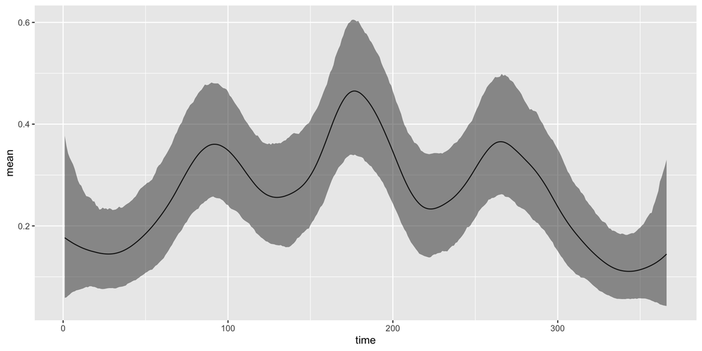

```r
preds$probs %>% ggplot() + geom_line(aes(time, mean)) +
  geom_ribbon(aes(time, ymin = q0.025, ymax = q0.975), alpha = 0.5)
```

## Example - `generate()`

```r
samples = generate(object = fit, newdata = Tokyo,
                ~ data.frame(time_eff = time,
                             lin_pred = Intercept + time,
                             probs = inv_logit(Intercept + time)),
                n.samples = 20
                )
# samples is now a list of length 20 (n.samples) each element of the list looks like:

samples[[1]][1:3,]
```

```
      time_eff   lin_pred     probs
1  0.145248856 -0.9073913 0.2875340
2 -0.008300456 -1.0609406 0.2571298
3 -0.126704192 -1.1793443 0.2351701
```

## Example - `generate()`

```r
data.frame(time = Tokyo$time, sapply(samples, function(x) x$probs)) %>%
  pivot_longer(-time) %>%
  ggplot() + geom_line(aes(time, value, group = name, color = factor(name))) +
  theme(legend.position = "none")
```

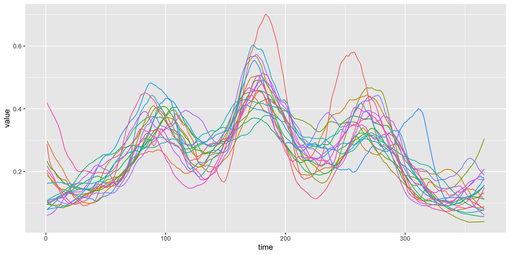

## The `_latent` suffix

- Sometimes, one wants to sample directly from latent parameters without specifying any new input data (or, in other words, to sample with an identity projection matrix)
- The keyword `_latent` can be appended to a latent component name to retrieve that

For example, the following code recovers the intercept and the time effect at day 13

```r
p = predict(object = fit, newdata = c(), ~ data.frame(int = Intercept_latent,
                                                      f_1 = time_latent[13]))
```

**NOTE** Here the `newdata` is just an empty object

# Manipulating posterior marginals

## Manipulating posterior marginals

We can be interested in functions of the posterior marginals that are computed by the `bru()` function.

For example, we might want to :

- compute the mean of a posterior marginal
- compute the median of a posterior marginal
- sample from the posterior marginal
- …

All this can be done with the help of the `inla.*marginal()` family of functions

## Example from the Tokyo example

```r
post_prec = fit$marginals.hyperpar$`Precision for time`
post_sd = inla.tmarginal(fun = function(x)
                          1/sqrt(x),
                         post_prec)
post_sd_mode = inla.mmarginal(post_sd)
post_sd_mean = inla.emarginal(fun =function(x)x, post_sd )
post_sd_sample = inla.rmarginal(1000, post_sd)
```

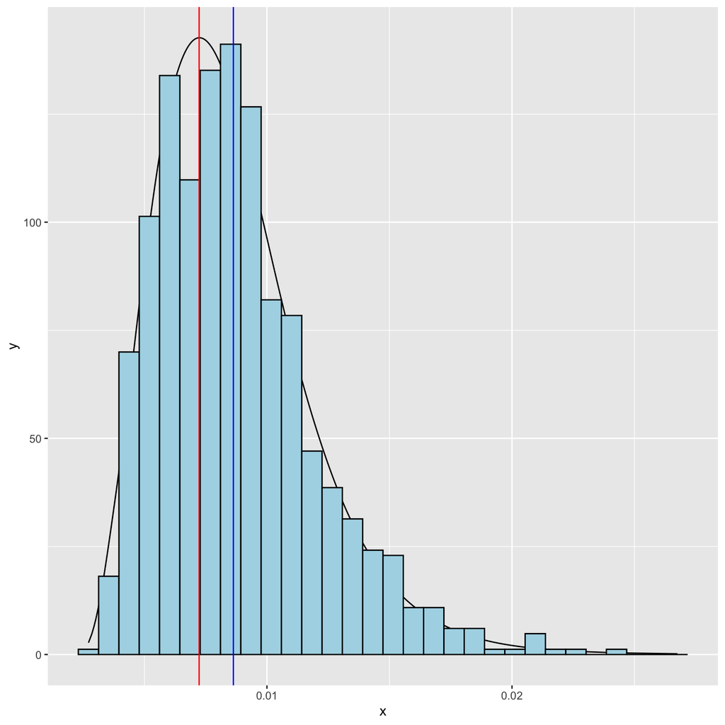

```r
ggplot() + geom_line(data = post_sd, aes(x,y))  +
  geom_histogram(data = data.frame(samples = post_sd_sample),
                 aes(x = samples, y = after_stat(density)),
                 color = "black", fill = "lightblue")+
  geom_vline(xintercept = post_sd_mode, color = "red") +
    geom_vline(xintercept = post_sd_mean, color = "blue")
```

## The `inla.*marginal()` family

| **Function Name** | **Usage** |
| --- | --- |
| `inla.dmarginal(x, marginal, ...)` | Density at a vector of evaluation points $x$ |
| `inla.pmarginal(q, marginal, ...)` | Distribution function at a vector of quantiles *q* |
| `inla.qmarginal(p, marginal, ...)` | Quantile function at a vector of probabilities *p* |
| `inla.rmarginal(n, marginal)` | Generate *n* random deviates |
| `inla.hpdmarginal(p, marginal, ...)` | Compute the highest posterior density interval at level *p* |
| `inla.emarginal(fun, marginal, ...)` | Compute the expected value assuming transformation given by *fun* |
| `inla.mmarginal(marginal)` | Computes the mode |
| `inla.smarginal(marginal, ...)` | Smoothed density (returns x-values and interpolated y-values) |
| `inla.tmarginal(fun, marginal, ...)` | Transform the marginal using function *fun* |
| `inla.zmarginal(marginal)` | Summary statistics for the marginal |

# `NA`s in `inlabru`

## Missing values in `inlabru`

The `bru()` function treats missing values in the dataset differently according to their role in the model.

Take the model definition:

```r
cmp = ~ Intercept(1) + covariate(x, model = "linear") + random(z, model = "iid")
formula = y ~ Intercept + covariate + random
```

- **`NA`’s in the response `y`**

  If `y[i] = NA`, this means that y[i] is not observed, hence gives no contribution to the likelihood.
- **`NA`’s in fixed effect `x`**

  If `x[i] = NA` this means that `x[i]` is not part of the linear predictor for `y[i]`. For fixed effects, this is equivalent to `x[i]=0`, hence internally we make this change: `x[is.na(x)] = 0`
- **`NA`’s in random effect `z`**

  If `z[i] = NA`, this means that the random effect does not contribute to the linear predictor for `y[i]`.

## Can `inlabru` deal with missing covariates?

No, `inlabru` has no way to `impute’ or integrate-out missing covariates.

You have to adjust your model to account for missing covariates.

Sometimes, you can formulate a joint model for the data and the covariates, but this is case-specific.

## Missing values when using `model = "fixed"`

When we use the `model = "fixed"` missing values can give error:

```r
df = data.frame(y = rnorm(5),
           x = as.factor(c("a","b", NA, "b", "a")))
cmp = ~ -1  + fixed(~x, model = "fixed")
lik = bru_obs(formula = y~.,
              data = df)
fit = bru(cmp, lik)
```

```
Error in `iinla()`:
! The total number of response values (N=5) and predictor values (N=4) do not match.
  This is likely due to a mistake in the component or predictor constructions.
```

The problem here is related to the `model.matrix()` function that is internally run and that, by default, removes the missing values

```r
dim(df)
```

```
[1] 5 2
```

```r
dim(model.matrix(~x, data = df))
```

```
[1] 4 2
```

This makes the length of the response (5) different from the length of the covariate (4).

One solution is to force `model.matrix()` not to remove the missing values

```r
options(na.action = "na.pass")
fit = bru(cmp, lik)
fit$summary.random$fixed[,c(1:4)]
```

```
           ID       mean        sd 0.025quant
1 (Intercept)  0.5621983 0.7106791 -0.8834028
2          xb -0.7319059 1.1232657 -3.0150691
```

**WARNING** this is a **global** options, it might interfere with other part of your code!

## Getting help while using `inlabru`

## Which priors have I used?

You might wonder which priors have you used in your model..

```r
fit = bru(cmp, lik)

INLA::inla.priors.used(fit)
```

**NB** `inla.priors.used` is a function of the `INLA` package, so you need to load it explicitly.

## Getting help!

The `inla.doc()` function provides help on the different prior, latent models and likelihood.

```r
inla.doc("ar1")
inla.doc("pc.prior")
inla.doc("gaussian")
```

## Which models are implemented?

**Likelihoods**

```r
# which likelihoods?
inla.list.models("likelihood")
```

```
Section [likelihood]
     0binomial                     New 0-inflated Binomial
     0binomialS                    New 0-inflated Binomial Swap
     0poisson                      New 0-inflated Poisson
     0poissonS                     New 0-inflated Poisson Swap
     1poisson                      New 1-inflated Poisson
     1poissonS                     New 1-inflated Poisson Swap
     agaussian                     The aggregated Gaussian likelihoood
     bcgaussian                    The Box-Cox Gaussian likelihoood
     bell                          The Bell likelihood
     beta                          The Beta likelihood
     betabinomial                  The Beta-Binomial likelihood
     betabinomialna                The Beta-Binomial Normal approximation likelihood
     bgev                          The blended Generalized Extreme Value likelihood
     binomial                      The Binomial likelihood
     binomialmix                   Binomial mixture
     cbinomial                     The clustered Binomial likelihood
     cennbinomial2                 The CenNegBinomial2 likelihood (similar to cenpoisson2)
     cenpoisson                    Then censored Poisson likelihood
     cenpoisson2                   Then censored Poisson likelihood (version 2)
     circularnormal                The circular Gaussian likelihoood
     cloglike                      User-defined likelihood
     coxph                         Cox-proportional hazard likelihood
     dgompertzsurv                 destructive gompertz (survival) distribution
     dgp                           Discrete generalized Pareto likelihood
     egp                           Exteneded Generalized Pareto likelihood
     exponential                   The Exponential likelihood
     exponentialsurv               The Exponential likelihood (survival)
     exppower                      The exponential power likelihoood
     fl                            The fl likelihood
     fmri                          fmri distribution (special nc-chi)
     fmrisurv                      fmri distribution (special nc-chi)
     gamma                         The Gamma likelihood
     gammacount                    A Gamma generalisation of the Poisson likelihood
     gammajw                       A special case of the Gamma likelihood
     gammajwsurv                   A special case of the Gamma likelihood (survival)
     gammasurv                     The Gamma likelihood (survival)
     gammasv                       The Gamma likelihood with constant rate
     gaussian                      The Gaussian likelihoood
     gaussianjw                    The GaussianJW likelihoood
```

[output cut: 57 more lines]

```
     zeroinflatedbinomial0         Zero-inflated Binomial, type 0
     zeroinflatedbinomial1         Zero-inflated Binomial, type 1
     zeroinflatedbinomial2         Zero-inflated Binomial, type 2
     zeroinflatedcenpoisson0       Zero-inflated censored Poisson, type 0
     zeroinflatedcenpoisson1       Zero-inflated censored Poisson, type 1
     zeroinflatednbinomial0        Zero inflated negBinomial, type 0
     zeroinflatednbinomial1        Zero inflated negBinomial, type 1
     zeroinflatednbinomial1strata2 Zero inflated negBinomial, type 1, strata 2
     zeroinflatednbinomial1strata3 Zero inflated negBinomial, type 1, strata 3
     zeroinflatednbinomial2        Zero inflated negBinomial, type 2
     zeroinflatedpoisson0          Zero-inflated Poisson, type 0
     zeroinflatedpoisson1          Zero-inflated Poisson, type 1
     zeroinflatedpoisson2          Zero-inflated Poisson, type 2
     zeroninflatedbinomial2        Zero and N inflated binomial, type 2
     zeroninflatedbinomial3        Zero and N inflated binomial, type 3
```

## Which models are implemented?

**Components**

```r
# which latent models? (components)
inla.list.models("latent")
```

```
Section [latent]
     2diid                         (This model is obsolute)
     ar                            Auto-regressive model of order p (AR(p))
     ar1                           Auto-regressive model of order 1 (AR(1))
     ar1c                          Auto-regressive model of order 1 w/covariates
     besag                         The Besag area model (CAR-model)
     besag2                        The shared Besag model
     besagproper                   A proper version of the Besag model
     besagproper2                  An alternative proper version of the Besag model
     bym                           The BYM-model (Besag-York-Mollier model)
     bym2                          The BYM-model with the PC priors
     cgeneric                      Generic latent model specified using C
     clinear                       Constrained linear effect
     copy                          Create a copy of a model component
     crw2                          Exact solution to the random walk of order 2
     dmatern                       Dense Matern field
     fgn                           Fractional Gaussian noise model
     fgn2                          Fractional Gaussian noise model (alt 2)
     generic                       A generic model
     generic0                      A generic model (type 0)
     generic1                      A generic model (type 1)
     generic2                      A generic model (type 2)
     generic3                      A generic model (type 3)
     iid                           Gaussian random effects in dim=1
     iid1d                         Gaussian random effect in dim=1 with Wishart prior
     iid2d                         Gaussian random effect in dim=2 with Wishart prior
     iid3d                         Gaussian random effect in dim=3 with Wishart prior
     iid4d                         Gaussian random effect in dim=4 with Wishart prior
     iid5d                         Gaussian random effect in dim=5 with Wishart prior
     iidkd                         Gaussian random effect in dim=k with Wishart prior
     intslope                      Intecept-slope model with Wishart-prior
     linear                        Alternative interface to an fixed effect
     log1exp                       A nonlinear model of a covariate
     logdist                       A nonlinear model of a covariate
     matern2d                      Matern covariance function on a regular grid
     meb                           Berkson measurement error model
     mec                           Classical measurement error model
     ou                            The Ornstein-Uhlenbeck process
     prw2                          Proper random walk of order 2
     revsigm                       Reverse sigmoidal effect of a covariate
     rgeneric                      Generic latent model specified using R
     rw1                           Random walk of order 1
     rw2                           Random walk of order 2
     rw2d                          Thin-plate spline model
     rw2diid                       Thin-plate spline with iid noise
     scopy                         Create a scopy of a model component
     seasonal                      Seasonal model for time series
     sigm                          Sigmoidal effect of a covariate
     slm                           Spatial lag model
     spde                          A SPDE model
     spde2                         A SPDE2 model
     spde3                         A SPDE3 model
     z                             The z-model in a classical mixed model formulation
```

## Which models are implemented?

**Priors**

```r
# which priors?
inla.list.models("prior")
```

```
Section [prior]
     betacorrelation               Beta prior for the correlation
     dirichlet                     Dirichlet prior
     expression:                   A generic prior defined using expressions
     flat                          A constant prior
     gamma                         Gamma prior
     gaussian                      Gaussian prior
     invalid                       Void prior
     jeffreystdf                   Jeffreys prior for the doc
     laplace                       Laplace prior
     linksnintercept               Skew-normal-link intercept-prior
     logflat                       A constant prior for log(theta)
     loggamma                      Log-Gamma prior
     logiflat                      A constant prior for log(1/theta)
     logitbeta                     Logit prior for a probability
     logtgaussian                  Truncated Gaussian prior
     logtnormal                    Truncated Normal prior
     minuslogsqrtruncnormal        (obsolete)
     mvnorm                        A multivariate Normal prior
     none                          No prior
     normal                        Normal prior
     pc                            Generic PC prior
     pc.alphaw                     PC prior for alpha in Weibull
     pc.ar                         PC prior for the AR(p) model
     pc.cor0                       PC prior correlation, basemodel cor=0
     pc.cor1                       PC prior correlation, basemodel cor=1
     pc.dof                        PC prior for log(dof-2)
     pc.egptail                    PC prior for the tail in the EGP likelihood
     pc.fgnh                       PC prior for the Hurst parameter in FGN
     pc.gamma                      PC prior for a Gamma parameter
     pc.gammacount                 PC prior for the GammaCount likelihood
     pc.gevtail                    PC prior for the tail in the GEV likelihood
     pc.matern                     PC prior for the Matern SPDE
     pc.mgamma                     PC prior for a Gamma parameter
     pc.prec                       PC prior for log(precision)
     pc.prw2.range                 PCprior for the range in PRW2
     pc.range                      PC prior for the range in the Matern SPDE
     pc.sn                         PC prior for the skew-normal
     pc.spde.GA                    (experimental)
     pom                           #classes-dependent prior for the POM model
     ref.ar                        Reference prior for the AR(p) model, p<=3
     rprior:                       A R-function defining the prior
     table:                        A generic tabulated prior
     wishart1d                     Wishart prior dim=1
     wishart2d                     Wishart prior dim=2
     wishart3d                     Wishart prior dim=3
     wishart4d                     Wishart prior dim=4
     wishart5d                     Wishart prior dim=5
     wishartkd                     Wishart prior
```

# Take home message

## Take home message

- Linear models with interactions
  - `inlabru` has a special model to implemement this
  - but it is also worth to understand that “fixed effects are *just* random efffects with fixed precision 😄
- `predict()` and `generate()` functions are powerful tools (based on sampling from the posterior distribution) to obtain many interesting results!
- missing values are usually not a problem but in some cases have to be treated carefully.